# R Notebook

Input data and clean column name

```r
result <- read.csv(file=file.choose()) #purchasing
productInfo <- read.csv(file=file.choose()) #product
branchLocation <- read.csv(file=file.choose()) #mappingforsale
result
```

| X_id | date | branch | purchase.product | purchase.quantity |
| --- | --- | --- | --- | --- |
| 5ef1ad188ebfae4c0cb3baeb | 2020-05-16 09:18:47 | Fanling | Warspite figure | 3 |
| 5ef1ad188ebfae4c0cb3baeb | 2020-05-16 09:18:47 | Fanling | Lucifer | 3 |
| 5ef1ad188ebfae4c0cb3baec | 2020-01-30 15:54:21 | Sha Tin | figma Nagato | 3 |
| 5ef1ad188ebfae4c0cb3baed | 2020-04-27 12:58:54 | Wan Chai | Mammon | 5 |
| 5ef1ad188ebfae4c0cb3baee | 2020-07-08 14:53:45 | Wan Chai | Asmodeus | 3 |
| 5ef1ad188ebfae4c0cb3baef | 2020-07-11 17:57:46 | TaiPo | Lucifer | 4 |
| 5ef1ad188ebfae4c0cb3baef | 2020-07-11 17:57:46 | TaiPo | Beelzebub | 3 |
| 5ef1ad188ebfae4c0cb3baef | 2020-07-11 17:57:46 | TaiPo | Leviathan | 5 |
| 5ef1ad188ebfae4c0cb3baef | 2020-07-11 17:57:46 | TaiPo | Maria Totsuka | 5 |
| 5ef1ad188ebfae4c0cb3baf0 | 2020-08-17 12:53:41 | Mon Kok | figma Nagato | 5 |

[output cut: 990 more lines]

```r
productInfo
```

| Product.Name | Description | Release.year | Manuifactor | Price |
| --- | --- | --- | --- | --- |
| figma Nagato | Kancolle Warship Nagato from famous web game kancolle | 2015 | AGP | 1409 |
| Warspite figure | Kancolle Warship Warsprite from famous web game kancolle | 2017 | KOTOBUKIYA | 1458 |
| Lucifer | Hobby Japan new Project, 7 sins: Pride | 2017 | Hobby Japan | 904 |
| Maria Totsuka | Hobby Japan new Project, Main Character of 7 sin. | 2017 | Hobby Japan | 1417 |
| Leviathan | Hobby Japan new Project, 7 sins: Jealousy | 2017 | Hobby Japan | 1497 |
| Belial | Hobby Japan new Project, 7 virtues: justice | 2018 | Hobby Japan | 956 |
| Satan | Hobby Japan new Project, 7 sins: wrath | 2018 | Hobby Japan | 853 |
| Belphegor | Hobby Japan new Project, 7 sins: Sloth | 2018 | Hobby Japan | 1328 |
| Mammon | Hobby Japan new Project, 7 sins:Greed | 2017 | Hobby Japan | 969 |
| Beelzebub | Hobby Japan new Project, 7 sins:Gluttony | 2017 | Hobby Japan | 1441 |

[output cut: 3 more lines]

```r
branchLocation
```

| landmark | lat | lon |
| --- | --- | --- |
| TaiPo | 22.45417 | 114.1628 |
| Sha Tin | 22.37728 | 114.1854 |
| Mon Kok | 22.31881 | 114.1688 |
| Fanling | 22.49921 | 114.1419 |
| Shum Shui Po | 22.33275 | 114.1624 |
| Tim Sha Tsui | 22.29904 | 114.1720 |
| Wan Chai | 22.27739 | 114.1777 |
| Yau Ma Tei | 22.31333 | 114.1707 |

```r
#clean the required dataset colum
colnames(result) <- c("billNumber","date","branch","product","quantity")
```

Merge Data with ProductInofo

```r
require(sqldf)
merge <- sqldf("Select * From [result] INNER JOIN [productInfo] ON result.product = productinfo.'product.Name'")
merge <- merge[,-c(6,7,8)]
merge
```

| billNumber | date | branch | product | quantity | Manuifactor | Price |
| --- | --- | --- | --- | --- | --- | --- |
| 5ef1ad188ebfae4c0cb3baeb | 2020-05-16 09:18:47 | Fanling | Warspite figure | 3 | KOTOBUKIYA | 1458 |
| 5ef1ad188ebfae4c0cb3baeb | 2020-05-16 09:18:47 | Fanling | Lucifer | 3 | Hobby Japan | 904 |
| 5ef1ad188ebfae4c0cb3baec | 2020-01-30 15:54:21 | Sha Tin | figma Nagato | 3 | AGP | 1409 |
| 5ef1ad188ebfae4c0cb3baed | 2020-04-27 12:58:54 | Wan Chai | Mammon | 5 | Hobby Japan | 969 |
| 5ef1ad188ebfae4c0cb3baee | 2020-07-08 14:53:45 | Wan Chai | Asmodeus | 3 | Hobby Japan | 1292 |
| 5ef1ad188ebfae4c0cb3baef | 2020-07-11 17:57:46 | TaiPo | Lucifer | 4 | Hobby Japan | 904 |
| 5ef1ad188ebfae4c0cb3baef | 2020-07-11 17:57:46 | TaiPo | Beelzebub | 3 | Hobby Japan | 1441 |
| 5ef1ad188ebfae4c0cb3baef | 2020-07-11 17:57:46 | TaiPo | Leviathan | 5 | Hobby Japan | 1497 |
| 5ef1ad188ebfae4c0cb3baef | 2020-07-11 17:57:46 | TaiPo | Maria Totsuka | 5 | Hobby Japan | 1417 |
| 5ef1ad188ebfae4c0cb3baf0 | 2020-08-17 12:53:41 | Mon Kok | figma Nagato | 5 | AGP | 1409 |

[output cut: 990 more lines]

Merge Data with branch Loaction

```r
mapping = sqldf("Select * From [merge] LEFT JOIN [branchLocation] ON merge.branch = branchLocation.landmark")
mapping
```

| billNumber | date | branch | product | quantity | Manuifactor | Price | landmark | lat | lon |
| --- | --- | --- | --- | --- | --- | --- | --- | --- | --- |
| 5ef1ad188ebfae4c0cb3baeb | 2020-05-16 09:18:47 | Fanling | Warspite figure | 3 | KOTOBUKIYA | 1458 | Fanling | 22.49921 | 114.1419 |
| 5ef1ad188ebfae4c0cb3baeb | 2020-05-16 09:18:47 | Fanling | Lucifer | 3 | Hobby Japan | 904 | Fanling | 22.49921 | 114.1419 |
| 5ef1ad188ebfae4c0cb3baec | 2020-01-30 15:54:21 | Sha Tin | figma Nagato | 3 | AGP | 1409 | Sha Tin | 22.37728 | 114.1854 |
| 5ef1ad188ebfae4c0cb3baed | 2020-04-27 12:58:54 | Wan Chai | Mammon | 5 | Hobby Japan | 969 | Wan Chai | 22.27739 | 114.1777 |
| 5ef1ad188ebfae4c0cb3baee | 2020-07-08 14:53:45 | Wan Chai | Asmodeus | 3 | Hobby Japan | 1292 | Wan Chai | 22.27739 | 114.1777 |
| 5ef1ad188ebfae4c0cb3baef | 2020-07-11 17:57:46 | TaiPo | Lucifer | 4 | Hobby Japan | 904 | TaiPo | 22.45417 | 114.1628 |
| 5ef1ad188ebfae4c0cb3baef | 2020-07-11 17:57:46 | TaiPo | Beelzebub | 3 | Hobby Japan | 1441 | TaiPo | 22.45417 | 114.1628 |
| 5ef1ad188ebfae4c0cb3baef | 2020-07-11 17:57:46 | TaiPo | Leviathan | 5 | Hobby Japan | 1497 | TaiPo | 22.45417 | 114.1628 |
| 5ef1ad188ebfae4c0cb3baef | 2020-07-11 17:57:46 | TaiPo | Maria Totsuka | 5 | Hobby Japan | 1417 | TaiPo | 22.45417 | 114.1628 |
| 5ef1ad188ebfae4c0cb3baf0 | 2020-08-17 12:53:41 | Mon Kok | figma Nagato | 5 | AGP | 1409 | Mon Kok | 22.31881 | 114.1688 |

[output cut: 990 more lines]

Calculate Revenue

```r
mapping$Revenue = mapping$Price * mapping$quantity
mapping
```

| billNumber | date | branch | product | quantity | Manuifactor | Price | landmark | lat | lon | Revenue |
| --- | --- | --- | --- | --- | --- | --- | --- | --- | --- | --- |
| 5ef1ad188ebfae4c0cb3baeb | 2020-05-16 09:18:47 | Fanling | Warspite figure | 3 | KOTOBUKIYA | 1458 | Fanling | 22.49921 | 114.1419 | 4374 |
| 5ef1ad188ebfae4c0cb3baeb | 2020-05-16 09:18:47 | Fanling | Lucifer | 3 | Hobby Japan | 904 | Fanling | 22.49921 | 114.1419 | 2712 |
| 5ef1ad188ebfae4c0cb3baec | 2020-01-30 15:54:21 | Sha Tin | figma Nagato | 3 | AGP | 1409 | Sha Tin | 22.37728 | 114.1854 | 4227 |
| 5ef1ad188ebfae4c0cb3baed | 2020-04-27 12:58:54 | Wan Chai | Mammon | 5 | Hobby Japan | 969 | Wan Chai | 22.27739 | 114.1777 | 4845 |
| 5ef1ad188ebfae4c0cb3baee | 2020-07-08 14:53:45 | Wan Chai | Asmodeus | 3 | Hobby Japan | 1292 | Wan Chai | 22.27739 | 114.1777 | 3876 |
| 5ef1ad188ebfae4c0cb3baef | 2020-07-11 17:57:46 | TaiPo | Lucifer | 4 | Hobby Japan | 904 | TaiPo | 22.45417 | 114.1628 | 3616 |
| 5ef1ad188ebfae4c0cb3baef | 2020-07-11 17:57:46 | TaiPo | Beelzebub | 3 | Hobby Japan | 1441 | TaiPo | 22.45417 | 114.1628 | 4323 |
| 5ef1ad188ebfae4c0cb3baef | 2020-07-11 17:57:46 | TaiPo | Leviathan | 5 | Hobby Japan | 1497 | TaiPo | 22.45417 | 114.1628 | 7485 |
| 5ef1ad188ebfae4c0cb3baef | 2020-07-11 17:57:46 | TaiPo | Maria Totsuka | 5 | Hobby Japan | 1417 | TaiPo | 22.45417 | 114.1628 | 7085 |
| 5ef1ad188ebfae4c0cb3baf0 | 2020-08-17 12:53:41 | Mon Kok | figma Nagato | 5 | AGP | 1409 | Mon Kok | 22.31881 | 114.1688 | 7045 |

[output cut: 990 more lines]

Summarise the Revuene by branch and Manuifactor

```r
final = NULL
branch = levels(factor(mapping$branch))
# branch = unique(mapping$branch)
branch
```

```
[1] "Fanling"      "Mon Kok"      "Sha Tin"      "Shum Shui Po" "TaiPo"        "Wan Chai"
```

```r
for(n in 1:length(branch)){
  partial = data.frame(branch[n], t(tapply(mapping[mapping$branch==branch[n],]$Revenue, mapping[mapping$branch==branch[n],]$Manuifactor, sum)))
  final =rbind(final, partial)
}

colnames(final) = c("branch", "AGP", "HobbyJapan","KOTOBUKIYA")
finalMapping <- sqldf("select * from [final] LEFT JOIN [branchLocation] ON final.branch = branchLocation.landmark")
finalMapping$landmark <- NULL
finalMapping
```

| branch | AGP | HobbyJapan | KOTOBUKIYA | lat | lon |
| --- | --- | --- | --- | --- | --- |
| Fanling | 44972462 | 409843188 | 45915336 | 22.49921 | 114.1419 |
| Mon Kok | 44211602 | 403555729 | 44836416 | 22.31881 | 114.1688 |
| Sha Tin | 44107336 | 405661539 | 46395018 | 22.37728 | 114.1854 |
| Shum Shui Po | 43459196 | 401364916 | 45769536 | 22.33275 | 114.1624 |
| TaiPo | 44566670 | 404739037 | 45493974 | 22.45417 | 114.1628 |
| Wan Chai | 44184831 | 407504696 | 46777014 | 22.27739 | 114.1777 |

```r
NA
```

Time-series analysis

```r
#Sys.setlocale(locale = "C") Ensure output is English
Sys.setlocale(locale = "C")
```

```
[1] "C/C/C/C/C/en_US.UTF-8"
```

```r
#Convert all date to timestamp
mapping$date = as.Date(mapping$date)
mapping$date
```

```
   [1] "2020-05-16" "2020-05-16" "2020-01-30" "2020-04-27" "2020-07-08" "2020-07-11" "2020-07-11"
   [8] "2020-07-11" "2020-07-11" "2020-08-17" "2020-08-17" "2020-08-01" "2020-08-01" "2020-08-01"
  [15] "2020-04-02" "2020-04-02" "2020-04-02" "2020-09-23" "2020-09-23" "2020-09-23" "2020-09-23"
  [22] "2020-06-29" "2020-06-29" "2020-06-29" "2020-06-07" "2020-06-07" "2020-11-17" "2020-11-17"
  [29] "2020-11-17" "2020-08-17" "2020-12-17" "2020-12-17" "2020-09-19" "2020-09-19" "2020-09-19"
  [36] "2020-09-19" "2020-06-19" "2020-06-19" "2020-06-19" "2020-02-22" "2020-02-22" "2020-02-22"
  [43] "2020-02-22" "2020-02-15" "2020-02-15" "2020-02-15" "2020-09-08" "2020-09-08" "2020-12-27"
  [50] "2020-12-27" "2020-12-27" "2020-12-27" "2020-07-01" "2020-07-07" "2020-03-29" "2020-03-29"
  [57] "2020-03-29" "2020-03-29" "2020-04-17" "2020-04-17" "2020-04-17" "2020-04-08" "2020-04-08"
  [64] "2020-04-08" "2020-04-25" "2020-04-25" "2020-04-25" "2020-04-25" "2020-04-07" "2020-04-07"
  [71] "2020-04-07" "2020-04-07" "2020-02-24" "2020-02-24" "2020-01-22" "2020-01-22" "2020-09-05"
  [78] "2020-04-01" "2020-04-01" "2020-02-11" "2020-02-11" "2020-02-11" "2020-02-11" "2020-04-27"
  [85] "2020-04-27" "2020-12-18" "2020-03-17" "2020-03-17" "2020-03-19" "2020-03-19" "2020-03-19"
  [92] "2020-02-14" "2020-02-14" "2020-02-14" "2020-02-14" "2020-09-05" "2020-09-05" "2020-09-05"
  [99] "2020-09-05" "2020-07-16" "2020-11-16" "2020-11-16" "2020-05-16" "2020-05-16" "2020-02-25"
```

[output cut: 129 more lines]

```r
mapping$Revenue
```

```
   [1] 4374 2712 4227 4845 3876 3616 4323 7485 7085 7045 3984 3824 4323 5988 3824 5168 7045 4323 5168
  [20] 4780 6260 3984 5008 5168 4227 4491 5045 7205 4265 2868 5988 3824 4323 4251 4227 7290 5764 4227
  [39] 3616 3616 3984 5764 4845 6640 7485 3824 5168 5008 2907 7085 3616 5636 5668 5764 4323 5008 4520
  [58] 4227 7085 4265 5008 4845 7045 7205 4265 3824 4323 2907 3984 5168 5988 3616 3876 4265 4227 6260
  [77] 2868 4845 3616 3984 4036 3756 5668 5636 2868 5312 5832 5008 3824 7205 7290 2712 4251 6640 4845
  [96] 5045 6260 5764 5312 2559 5668 4780 2868 4520 5168 3984 7085 7485 7290 4036 4845 7290 2907 2907
 [115] 2559 7085 5764 4251 7045 6260 3984 6460 5988 5045 3824 7085 3412 5312 5636 4520 5045 3876 3616
 [134] 4036 3876 2907 7085 5008 3876 3876 4036 4036 7085 3876 3616 2907 4251 5832 7205 4251 4036 4374
 [153] 3876 5636 7205 5764 6460 2559 2868 5168 7085 3824 4845 7085 7290 5988 3824 6260 3984 4265 7085
 [172] 7290 3616 3756 6460 2712 3876 5832 4491 4374 2868 2712 3876 3984 3027 6640 3876 4845 3027 2559
 [191] 5312 3876 5832 4323 2559 5008 3984 7085 4780 4520 4227 5045 4845 3876 4323 5168 5832 5988 6460
 [210] 7290 3412 2907 2712 6460 2712 4374 3876 3412 3027 4845 5764 4780 7485 5668 6640 4845 7290 4227
 [229] 4845 2559 4374 4780 3027 3756 3876 3984 5045 4780 2712 7045 4780 7085 5668 6460 4780 2868 5008
 [248] 7290 7290 4251 7045 3876 5668 4520 2868 4845 5168 7485 5008 2712 4323 4780 7045 4036 4491 5764
 [267] 7205 3824 4251 3616 3027 7290 4845 5988 4323 2559 6260 3027 4227 4780 4845 3412 4323 4491 4374
```

[output cut: 39 more lines]

```r
#calculate time-series Revenue and form as data frame
times = data.frame(mapping$date, mapping$Revenue)
times
```

| mapping.date | mapping.Revenue |
| --- | --- |
| 2020-05-16 | 4374 |
| 2020-05-16 | 2712 |
| 2020-01-30 | 4227 |
| 2020-04-27 | 4845 |
| 2020-07-08 | 3876 |
| 2020-07-11 | 3616 |
| 2020-07-11 | 4323 |
| 2020-07-11 | 7485 |
| 2020-07-11 | 7085 |
| 2020-08-17 | 7045 |

[output cut: 990 more lines]

```r
#Extract Month value from dataframe

times$month = format(times$mapping.date, "%B")
times
```

| mapping.date | mapping.Revenue | month |
| --- | --- | --- |
| 2020-05-16 | 4374 | May |
| 2020-05-16 | 2712 | May |
| 2020-01-30 | 4227 | January |
| 2020-04-27 | 4845 | April |
| 2020-07-08 | 3876 | July |
| 2020-07-11 | 3616 | July |
| 2020-07-11 | 4323 | July |
| 2020-07-11 | 7485 | July |
| 2020-07-11 | 7085 | July |
| 2020-08-17 | 7045 | August |

[output cut: 990 more lines]

```r
times = tapply(times$mapping.Revenue, times$month, sum)
times
```

```
    April    August  December  February   January      July      June     March       May  November
247433862 247842054 246352169 247465154 243503708 249540660 250701872 243194513 250426246 246895031
  October September
251266885 248736342
```

```r
#Calculate Monthly Revenue
times <- as.data.frame(times)
times$month <- rownames(times)
times <- times[order(factor(times$month,levels=month.name)),]
times
```

|  | times | month |
| --- | --- | --- |
| January | 243503708 | January |
| February | 247465154 | February |
| March | 243194513 | March |
| April | 247433862 | April |
| May | 250426246 | May |
| June | 250701872 | June |
| July | 249540660 | July |
| August | 247842054 | August |
| September | 248736342 | September |
| October | 251266885 | October |

[output cut: 2 more lines]

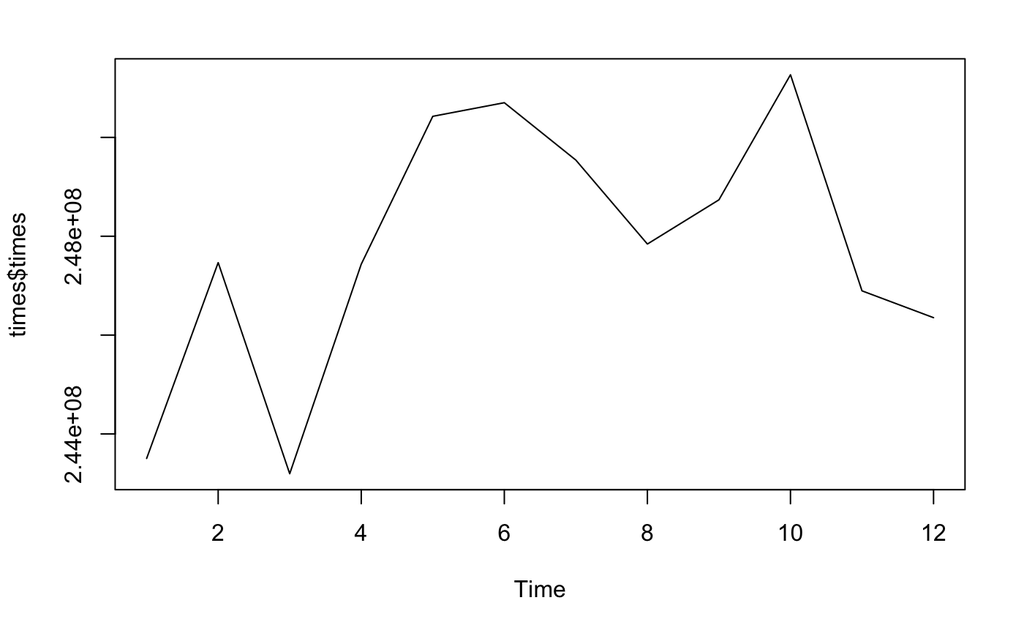

```r
#plot time-series trend by monthly basis
plot.ts(times$times)
```

The EM algorithm

```r
#install.packages("mixtools")
require(mixtools)
#calculate a column of data about total number of quantity from each bill
mapping
```

| billNumber | date | branch | product | quantity | Manuifactor | Price | landmark | lat | lon | Revenue |
| --- | --- | --- | --- | --- | --- | --- | --- | --- | --- | --- |
| 5ef1ad188ebfae4c0cb3baeb | 2020-05-16 | Fanling | Warspite figure | 3 | KOTOBUKIYA | 1458 | Fanling | 22.49921 | 114.1419 | 4374 |
| 5ef1ad188ebfae4c0cb3baeb | 2020-05-16 | Fanling | Lucifer | 3 | Hobby Japan | 904 | Fanling | 22.49921 | 114.1419 | 2712 |
| 5ef1ad188ebfae4c0cb3baec | 2020-01-30 | Sha Tin | figma Nagato | 3 | AGP | 1409 | Sha Tin | 22.37728 | 114.1854 | 4227 |
| 5ef1ad188ebfae4c0cb3baed | 2020-04-27 | Wan Chai | Mammon | 5 | Hobby Japan | 969 | Wan Chai | 22.27739 | 114.1777 | 4845 |
| 5ef1ad188ebfae4c0cb3baee | 2020-07-08 | Wan Chai | Asmodeus | 3 | Hobby Japan | 1292 | Wan Chai | 22.27739 | 114.1777 | 3876 |
| 5ef1ad188ebfae4c0cb3baef | 2020-07-11 | TaiPo | Lucifer | 4 | Hobby Japan | 904 | TaiPo | 22.45417 | 114.1628 | 3616 |
| 5ef1ad188ebfae4c0cb3baef | 2020-07-11 | TaiPo | Beelzebub | 3 | Hobby Japan | 1441 | TaiPo | 22.45417 | 114.1628 | 4323 |
| 5ef1ad188ebfae4c0cb3baef | 2020-07-11 | TaiPo | Leviathan | 5 | Hobby Japan | 1497 | TaiPo | 22.45417 | 114.1628 | 7485 |
| 5ef1ad188ebfae4c0cb3baef | 2020-07-11 | TaiPo | Maria Totsuka | 5 | Hobby Japan | 1417 | TaiPo | 22.45417 | 114.1628 | 7085 |
| 5ef1ad188ebfae4c0cb3baf0 | 2020-08-17 | Mon Kok | figma Nagato | 5 | AGP | 1409 | Mon Kok | 22.31881 | 114.1688 | 7045 |

[output cut: 990 more lines]

```r
bill = tapply(mapping$quantity, mapping$billNumber, sum)
bill
```

```
5ef1ad188ebfae4c0cb3baeb 5ef1ad188ebfae4c0cb3baec 5ef1ad188ebfae4c0cb3baed 5ef1ad188ebfae4c0cb3baee
                       6                        3                        5                        3
5ef1ad188ebfae4c0cb3baef 5ef1ad188ebfae4c0cb3baf0 5ef1ad188ebfae4c0cb3baf1 5ef1ad188ebfae4c0cb3baf2
                      17                        8                       11                       13
5ef1ad188ebfae4c0cb3baf3 5ef1ad188ebfae4c0cb3baf4 5ef1ad188ebfae4c0cb3baf5 5ef1ad188ebfae4c0cb3baf6
                      17                       11                        6                       15
5ef1ad188ebfae4c0cb3baf7 5ef1ad188ebfae4c0cb3baf8 5ef1ad188ebfae4c0cb3baf9 5ef1ad188ebfae4c0cb3bafa
                       3                        8                       14                       11
5ef1ad188ebfae4c0cb3bafb 5ef1ad188ebfae4c0cb3bafc 5ef1ad188ebfae4c0cb3bafd 5ef1ad188ebfae4c0cb3bafe
                      16                       14                        8                       16
5ef1ad188ebfae4c0cb3baff 5ef1ad188ebfae4c0cb3bb00 5ef1ad188ebfae4c0cb3bb01 5ef1ad188ebfae4c0cb3bb02
                       4                        4                       15                       14
5ef1ad188ebfae4c0cb3bb03 5ef1ad188ebfae4c0cb3bb04 5ef1ad188ebfae4c0cb3bb05 5ef1ad188ebfae4c0cb3bb06
                      15                       15                       15                        9
5ef1ad188ebfae4c0cb3bb07 5ef1ad188ebfae4c0cb3bb08 5ef1ad188ebfae4c0cb3bb09 5ef1ad188ebfae4c0cb3bb0a
                       8                        3                        9                       14
5ef1ad188ebfae4c0cb3bb0b 5ef1ad188ebfae4c0cb3bb0c 5ef1ad188ebfae4c0cb3bb0d 5ef1ad188ebfae4c0cb3bb0e
                       7                        4                        8                       14
5ef1ad188ebfae4c0cb3bb0f 5ef1ad188ebfae4c0cb3bb10 5ef1ad188ebfae4c0cb3bb11 5ef1ad188ebfae4c0cb3bb12
                      16                       18                        3                        9
5ef1ad188ebfae4c0cb3bb13 5ef1ad188ebfae4c0cb3bb14 5ef1ad188ebfae4c0cb3bb15 5ef1ad188ebfae4c0cb3bb16
                       8                        4                       13                       14
5ef1ad188ebfae4c0cb3bb17 5ef1ad188ebfae4c0cb3bb18 5ef1ad188ebfae4c0cb3bb19 5ef1ad188ebfae4c0cb3bb1a
                       8                       15                       13                       12
5ef1ad188ebfae4c0cb3bb1b 5ef1ad188ebfae4c0cb3bb1c 5ef1ad188ebfae4c0cb3bb1d 5ef1ad188ebfae4c0cb3bb1e
                       5                       17                       14                        8
5ef1ad188ebfae4c0cb3bb1f 5ef1ad188ebfae4c0cb3bb20 5ef1ad188ebfae4c0cb3bb21 5ef1ad188ebfae4c0cb3bb22
                       4                       15                       11                       16
5ef1ad188ebfae4c0cb3bb23 5ef1ad188ebfae4c0cb3bb24 5ef1ad188ebfae4c0cb3bb25 5ef1ad188ebfae4c0cb3bb26
                      10                       15                       13                        9
5ef1ad188ebfae4c0cb3bb27 5ef1ad188ebfae4c0cb3bb28 5ef1ad188ebfae4c0cb3bb29 5ef1ad188ebfae4c0cb3bb2a
                       6                       18                        5                       18
5ef1ad188ebfae4c0cb3bb2b 5ef1ad188ebfae4c0cb3bb2c 5ef1ad188ebfae4c0cb3bb2d 5ef1ad188ebfae4c0cb3bb2e
                       8                       14                       15                        7
5ef1ad188ebfae4c0cb3bb2f 5ef1ad188ebfae4c0cb3bb30 5ef1ad188ebfae4c0cb3bb31 5ef1ad188ebfae4c0cb3bb32
                       6                        3                       10                        5
5ef1ad188ebfae4c0cb3bb33 5ef1ad188ebfae4c0cb3bb34 5ef1ad188ebfae4c0cb3bb35 5ef1ad188ebfae4c0cb3bb36
                       8                       10                       11                        7
5ef1ad188ebfae4c0cb3bb37 5ef1ad188ebfae4c0cb3bb38 5ef1ad188ebfae4c0cb3bb39 5ef1ad188ebfae4c0cb3bb3a
                      18                       13                       15                        9
```

[output cut: 446 more lines]

```
5ef1ad188ebfae4c0cb3beb7 5ef1ad188ebfae4c0cb3beb8 5ef1ad188ebfae4c0cb3beb9 5ef1ad188ebfae4c0cb3beba
                      16                        4                       11                        3
5ef1ad188ebfae4c0cb3bebb 5ef1ad188ebfae4c0cb3bebc 5ef1ad188ebfae4c0cb3bebd 5ef1ad188ebfae4c0cb3bebe
                      17                       17                       14                       16
5ef1ad188ebfae4c0cb3bebf 5ef1ad188ebfae4c0cb3bec0 5ef1ad188ebfae4c0cb3bec1 5ef1ad188ebfae4c0cb3bec2
                       3                        8                        3                        4
5ef1ad188ebfae4c0cb3bec3 5ef1ad188ebfae4c0cb3bec4 5ef1ad188ebfae4c0cb3bec5 5ef1ad188ebfae4c0cb3bec6
                      12                        5                       15                       16
5ef1ad188ebfae4c0cb3bec7 5ef1ad188ebfae4c0cb3bec8 5ef1ad188ebfae4c0cb3bec9 5ef1ad188ebfae4c0cb3beca
                      13                       10                        6                        3
5ef1ad188ebfae4c0cb3becb 5ef1ad188ebfae4c0cb3becc 5ef1ad188ebfae4c0cb3becd 5ef1ad188ebfae4c0cb3bece
                      13                       18                        4                        9
5ef1ad188ebfae4c0cb3becf 5ef1ad188ebfae4c0cb3bed0 5ef1ad188ebfae4c0cb3bed1 5ef1ad188ebfae4c0cb3bed2
                       5                        7                        5                        4
 [ reached getOption("max.print") -- omitted 244016 entries ]
```

```r
bill <- as.data.frame(bill)
bill$billNumber <- rownames(bill)
bill <- bill[order(factor(bill$billNumber,levels=bill$billNumber.name)),]
bill
```

|  | bill | billNumber |
| --- | --- | --- |
| 5ef1ad188ebfae4c0cb3baeb | 6 | 5ef1ad188ebfae4c0cb3baeb |
| 5ef1ad188ebfae4c0cb3baec | 3 | 5ef1ad188ebfae4c0cb3baec |
| 5ef1ad188ebfae4c0cb3baed | 5 | 5ef1ad188ebfae4c0cb3baed |
| 5ef1ad188ebfae4c0cb3baee | 3 | 5ef1ad188ebfae4c0cb3baee |
| 5ef1ad188ebfae4c0cb3baef | 17 | 5ef1ad188ebfae4c0cb3baef |
| 5ef1ad188ebfae4c0cb3baf0 | 8 | 5ef1ad188ebfae4c0cb3baf0 |
| 5ef1ad188ebfae4c0cb3baf1 | 11 | 5ef1ad188ebfae4c0cb3baf1 |
| 5ef1ad188ebfae4c0cb3baf2 | 13 | 5ef1ad188ebfae4c0cb3baf2 |
| 5ef1ad188ebfae4c0cb3baf3 | 17 | 5ef1ad188ebfae4c0cb3baf3 |
| 5ef1ad188ebfae4c0cb3baf4 | 11 | 5ef1ad188ebfae4c0cb3baf4 |

[output cut: 990 more lines]

```r
#EM model
bill1 = normalmixEM(bill$bill, k=2, fast=TRUE)
```

```
number of iterations= 902
```

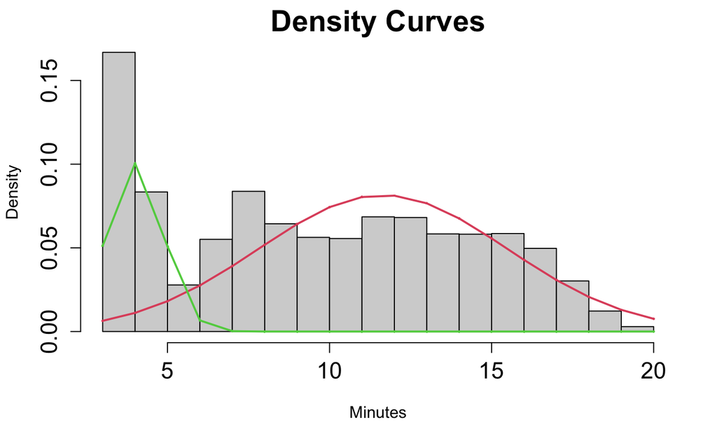

```r
plot(bill1, density=TRUE, cex.axis=1.4,cex.lab=1, cex.main=1.8, whichplot=2, xlab2="Minutes",ask=FALSE)
```

clustering

```r
#install.packages("mclust")
require(mclust)
#build columns of data about Revenue from each bill
mapping
```

| billNumber | date | branch | product | quantity | Manuifactor | Price | landmark | lat | lon | Revenue |
| --- | --- | --- | --- | --- | --- | --- | --- | --- | --- | --- |
| 5ef1ad188ebfae4c0cb3baeb | 2020-05-16 | Fanling | Warspite figure | 3 | KOTOBUKIYA | 1458 | Fanling | 22.49921 | 114.1419 | 4374 |
| 5ef1ad188ebfae4c0cb3baeb | 2020-05-16 | Fanling | Lucifer | 3 | Hobby Japan | 904 | Fanling | 22.49921 | 114.1419 | 2712 |
| 5ef1ad188ebfae4c0cb3baec | 2020-01-30 | Sha Tin | figma Nagato | 3 | AGP | 1409 | Sha Tin | 22.37728 | 114.1854 | 4227 |
| 5ef1ad188ebfae4c0cb3baed | 2020-04-27 | Wan Chai | Mammon | 5 | Hobby Japan | 969 | Wan Chai | 22.27739 | 114.1777 | 4845 |
| 5ef1ad188ebfae4c0cb3baee | 2020-07-08 | Wan Chai | Asmodeus | 3 | Hobby Japan | 1292 | Wan Chai | 22.27739 | 114.1777 | 3876 |
| 5ef1ad188ebfae4c0cb3baef | 2020-07-11 | TaiPo | Lucifer | 4 | Hobby Japan | 904 | TaiPo | 22.45417 | 114.1628 | 3616 |
| 5ef1ad188ebfae4c0cb3baef | 2020-07-11 | TaiPo | Beelzebub | 3 | Hobby Japan | 1441 | TaiPo | 22.45417 | 114.1628 | 4323 |
| 5ef1ad188ebfae4c0cb3baef | 2020-07-11 | TaiPo | Leviathan | 5 | Hobby Japan | 1497 | TaiPo | 22.45417 | 114.1628 | 7485 |
| 5ef1ad188ebfae4c0cb3baef | 2020-07-11 | TaiPo | Maria Totsuka | 5 | Hobby Japan | 1417 | TaiPo | 22.45417 | 114.1628 | 7085 |
| 5ef1ad188ebfae4c0cb3baf0 | 2020-08-17 | Mon Kok | figma Nagato | 5 | AGP | 1409 | Mon Kok | 22.31881 | 114.1688 | 7045 |

[output cut: 990 more lines]

```r
clust = tapply(mapping$Revenue, mapping$billNumber, sum)
clust
```

```
5ef1ad188ebfae4c0cb3baeb 5ef1ad188ebfae4c0cb3baec 5ef1ad188ebfae4c0cb3baed 5ef1ad188ebfae4c0cb3baee
                    7086                     4227                     4845                     3876
5ef1ad188ebfae4c0cb3baef 5ef1ad188ebfae4c0cb3baf0 5ef1ad188ebfae4c0cb3baf1 5ef1ad188ebfae4c0cb3baf2
                   22509                    11029                    14135                    16037
5ef1ad188ebfae4c0cb3baf3 5ef1ad188ebfae4c0cb3baf4 5ef1ad188ebfae4c0cb3baf5 5ef1ad188ebfae4c0cb3baf6
                   20531                    14160                     8718                    16515
5ef1ad188ebfae4c0cb3baf7 5ef1ad188ebfae4c0cb3baf8 5ef1ad188ebfae4c0cb3baf9 5ef1ad188ebfae4c0cb3bafa
                    2868                     9812                    20091                    13607
5ef1ad188ebfae4c0cb3bafb 5ef1ad188ebfae4c0cb3bafc 5ef1ad188ebfae4c0cb3bafd 5ef1ad188ebfae4c0cb3bafe
                   18209                    17949                    10176                    19244
5ef1ad188ebfae4c0cb3baff 5ef1ad188ebfae4c0cb3bb00 5ef1ad188ebfae4c0cb3bb01 5ef1ad188ebfae4c0cb3bb02
                    5668                     5764                    18078                    16358
5ef1ad188ebfae4c0cb3bb03 5ef1ad188ebfae4c0cb3bb04 5ef1ad188ebfae4c0cb3bb05 5ef1ad188ebfae4c0cb3bb06
                   19095                    15319                    18756                     8141
5ef1ad188ebfae4c0cb3bb07 5ef1ad188ebfae4c0cb3bb08 5ef1ad188ebfae4c0cb3bb09 5ef1ad188ebfae4c0cb3bb0a
                   10487                     2868                     8461                    17444
5ef1ad188ebfae4c0cb3bb0b 5ef1ad188ebfae4c0cb3bb0c 5ef1ad188ebfae4c0cb3bb0d 5ef1ad188ebfae4c0cb3bb0e
                    8504                     5312                    10840                    18319
5ef1ad188ebfae4c0cb3bb0f 5ef1ad188ebfae4c0cb3bb10 5ef1ad188ebfae4c0cb3bb11 5ef1ad188ebfae4c0cb3bb12
                   18448                    22381                     2559                    10448
5ef1ad188ebfae4c0cb3bb13 5ef1ad188ebfae4c0cb3bb14 5ef1ad188ebfae4c0cb3bb15 5ef1ad188ebfae4c0cb3bb16
                    7388                     5168                    18554                    16171
5ef1ad188ebfae4c0cb3bb17 5ef1ad188ebfae4c0cb3bb18 5ef1ad188ebfae4c0cb3bb19 5ef1ad188ebfae4c0cb3bb1a
                   10197                    18315                    17556                    16432
5ef1ad188ebfae4c0cb3bb1b 5ef1ad188ebfae4c0cb3bb1c 5ef1ad188ebfae4c0cb3bb1d 5ef1ad188ebfae4c0cb3bb1e
                    5045                    19633                    15201                     7492
5ef1ad188ebfae4c0cb3bb1f 5ef1ad188ebfae4c0cb3bb20 5ef1ad188ebfae4c0cb3bb21 5ef1ad188ebfae4c0cb3bb22
                    4036                    18876                    11788                    18613
5ef1ad188ebfae4c0cb3bb23 5ef1ad188ebfae4c0cb3bb24 5ef1ad188ebfae4c0cb3bb25 5ef1ad188ebfae4c0cb3bb26
                   12990                    19866                    16717                    12224
5ef1ad188ebfae4c0cb3bb27 5ef1ad188ebfae4c0cb3bb28 5ef1ad188ebfae4c0cb3bb29 5ef1ad188ebfae4c0cb3bb2a
                    5427                    20922                     7085                    23362
5ef1ad188ebfae4c0cb3bb2b 5ef1ad188ebfae4c0cb3bb2c 5ef1ad188ebfae4c0cb3bb2d 5ef1ad188ebfae4c0cb3bb2e
                    8249                    17991                    16804                    10323
5ef1ad188ebfae4c0cb3bb2f 5ef1ad188ebfae4c0cb3bb30 5ef1ad188ebfae4c0cb3bb31 5ef1ad188ebfae4c0cb3bb32
                    7242                     2712                    10887                     6640
5ef1ad188ebfae4c0cb3bb33 5ef1ad188ebfae4c0cb3bb34 5ef1ad188ebfae4c0cb3bb35 5ef1ad188ebfae4c0cb3bb36
                    8721                    10898                    14031                     7567
5ef1ad188ebfae4c0cb3bb37 5ef1ad188ebfae4c0cb3bb38 5ef1ad188ebfae4c0cb3bb39 5ef1ad188ebfae4c0cb3bb3a
                   20369                    14117                    19199                    12448
```

[output cut: 446 more lines]

```
5ef1ad188ebfae4c0cb3beb7 5ef1ad188ebfae4c0cb3beb8 5ef1ad188ebfae4c0cb3beb9 5ef1ad188ebfae4c0cb3beba
                   16699                     5668                    13910                     4491
5ef1ad188ebfae4c0cb3bebb 5ef1ad188ebfae4c0cb3bebc 5ef1ad188ebfae4c0cb3bebd 5ef1ad188ebfae4c0cb3bebe
                   17883                    16373                    15526                    18440
5ef1ad188ebfae4c0cb3bebf 5ef1ad188ebfae4c0cb3bec0 5ef1ad188ebfae4c0cb3bec1 5ef1ad188ebfae4c0cb3bec2
                    3027                    10512                     3984                     3412
5ef1ad188ebfae4c0cb3bec3 5ef1ad188ebfae4c0cb3bec4 5ef1ad188ebfae4c0cb3bec5 5ef1ad188ebfae4c0cb3bec6
                   14793                     4845                    19179                    22027
5ef1ad188ebfae4c0cb3bec7 5ef1ad188ebfae4c0cb3bec8 5ef1ad188ebfae4c0cb3bec9 5ef1ad188ebfae4c0cb3beca
                   17221                    11451                     6786                     2907
5ef1ad188ebfae4c0cb3becb 5ef1ad188ebfae4c0cb3becc 5ef1ad188ebfae4c0cb3becd 5ef1ad188ebfae4c0cb3bece
                   16393                    23258                     5008                    11166
5ef1ad188ebfae4c0cb3becf 5ef1ad188ebfae4c0cb3bed0 5ef1ad188ebfae4c0cb3bed1 5ef1ad188ebfae4c0cb3bed2
                    6640                     9491                     4780                     5008
 [ reached getOption("max.print") -- omitted 244016 entries ]
```

```r
clust <- as.data.frame(clust)
clust$billNumber <- rownames(clust)
clust <- clust[order(factor(clust$billNumber,levels=clust$billNumber.name)),]

#build columns of data about total number of quantity from each bill
clust1 = tapply(mapping$quantity, mapping$billNumber, sum)
clust1
```

```
5ef1ad188ebfae4c0cb3baeb 5ef1ad188ebfae4c0cb3baec 5ef1ad188ebfae4c0cb3baed 5ef1ad188ebfae4c0cb3baee
                       6                        3                        5                        3
5ef1ad188ebfae4c0cb3baef 5ef1ad188ebfae4c0cb3baf0 5ef1ad188ebfae4c0cb3baf1 5ef1ad188ebfae4c0cb3baf2
                      17                        8                       11                       13
5ef1ad188ebfae4c0cb3baf3 5ef1ad188ebfae4c0cb3baf4 5ef1ad188ebfae4c0cb3baf5 5ef1ad188ebfae4c0cb3baf6
                      17                       11                        6                       15
5ef1ad188ebfae4c0cb3baf7 5ef1ad188ebfae4c0cb3baf8 5ef1ad188ebfae4c0cb3baf9 5ef1ad188ebfae4c0cb3bafa
                       3                        8                       14                       11
5ef1ad188ebfae4c0cb3bafb 5ef1ad188ebfae4c0cb3bafc 5ef1ad188ebfae4c0cb3bafd 5ef1ad188ebfae4c0cb3bafe
                      16                       14                        8                       16
5ef1ad188ebfae4c0cb3baff 5ef1ad188ebfae4c0cb3bb00 5ef1ad188ebfae4c0cb3bb01 5ef1ad188ebfae4c0cb3bb02
                       4                        4                       15                       14
5ef1ad188ebfae4c0cb3bb03 5ef1ad188ebfae4c0cb3bb04 5ef1ad188ebfae4c0cb3bb05 5ef1ad188ebfae4c0cb3bb06
                      15                       15                       15                        9
5ef1ad188ebfae4c0cb3bb07 5ef1ad188ebfae4c0cb3bb08 5ef1ad188ebfae4c0cb3bb09 5ef1ad188ebfae4c0cb3bb0a
                       8                        3                        9                       14
5ef1ad188ebfae4c0cb3bb0b 5ef1ad188ebfae4c0cb3bb0c 5ef1ad188ebfae4c0cb3bb0d 5ef1ad188ebfae4c0cb3bb0e
                       7                        4                        8                       14
5ef1ad188ebfae4c0cb3bb0f 5ef1ad188ebfae4c0cb3bb10 5ef1ad188ebfae4c0cb3bb11 5ef1ad188ebfae4c0cb3bb12
                      16                       18                        3                        9
5ef1ad188ebfae4c0cb3bb13 5ef1ad188ebfae4c0cb3bb14 5ef1ad188ebfae4c0cb3bb15 5ef1ad188ebfae4c0cb3bb16
                       8                        4                       13                       14
5ef1ad188ebfae4c0cb3bb17 5ef1ad188ebfae4c0cb3bb18 5ef1ad188ebfae4c0cb3bb19 5ef1ad188ebfae4c0cb3bb1a
                       8                       15                       13                       12
5ef1ad188ebfae4c0cb3bb1b 5ef1ad188ebfae4c0cb3bb1c 5ef1ad188ebfae4c0cb3bb1d 5ef1ad188ebfae4c0cb3bb1e
                       5                       17                       14                        8
5ef1ad188ebfae4c0cb3bb1f 5ef1ad188ebfae4c0cb3bb20 5ef1ad188ebfae4c0cb3bb21 5ef1ad188ebfae4c0cb3bb22
                       4                       15                       11                       16
5ef1ad188ebfae4c0cb3bb23 5ef1ad188ebfae4c0cb3bb24 5ef1ad188ebfae4c0cb3bb25 5ef1ad188ebfae4c0cb3bb26
                      10                       15                       13                        9
5ef1ad188ebfae4c0cb3bb27 5ef1ad188ebfae4c0cb3bb28 5ef1ad188ebfae4c0cb3bb29 5ef1ad188ebfae4c0cb3bb2a
                       6                       18                        5                       18
5ef1ad188ebfae4c0cb3bb2b 5ef1ad188ebfae4c0cb3bb2c 5ef1ad188ebfae4c0cb3bb2d 5ef1ad188ebfae4c0cb3bb2e
                       8                       14                       15                        7
5ef1ad188ebfae4c0cb3bb2f 5ef1ad188ebfae4c0cb3bb30 5ef1ad188ebfae4c0cb3bb31 5ef1ad188ebfae4c0cb3bb32
                       6                        3                       10                        5
5ef1ad188ebfae4c0cb3bb33 5ef1ad188ebfae4c0cb3bb34 5ef1ad188ebfae4c0cb3bb35 5ef1ad188ebfae4c0cb3bb36
                       8                       10                       11                        7
5ef1ad188ebfae4c0cb3bb37 5ef1ad188ebfae4c0cb3bb38 5ef1ad188ebfae4c0cb3bb39 5ef1ad188ebfae4c0cb3bb3a
                      18                       13                       15                        9
```

[output cut: 446 more lines]

```
5ef1ad188ebfae4c0cb3beb7 5ef1ad188ebfae4c0cb3beb8 5ef1ad188ebfae4c0cb3beb9 5ef1ad188ebfae4c0cb3beba
                      16                        4                       11                        3
5ef1ad188ebfae4c0cb3bebb 5ef1ad188ebfae4c0cb3bebc 5ef1ad188ebfae4c0cb3bebd 5ef1ad188ebfae4c0cb3bebe
                      17                       17                       14                       16
5ef1ad188ebfae4c0cb3bebf 5ef1ad188ebfae4c0cb3bec0 5ef1ad188ebfae4c0cb3bec1 5ef1ad188ebfae4c0cb3bec2
                       3                        8                        3                        4
5ef1ad188ebfae4c0cb3bec3 5ef1ad188ebfae4c0cb3bec4 5ef1ad188ebfae4c0cb3bec5 5ef1ad188ebfae4c0cb3bec6
                      12                        5                       15                       16
5ef1ad188ebfae4c0cb3bec7 5ef1ad188ebfae4c0cb3bec8 5ef1ad188ebfae4c0cb3bec9 5ef1ad188ebfae4c0cb3beca
                      13                       10                        6                        3
5ef1ad188ebfae4c0cb3becb 5ef1ad188ebfae4c0cb3becc 5ef1ad188ebfae4c0cb3becd 5ef1ad188ebfae4c0cb3bece
                      13                       18                        4                        9
5ef1ad188ebfae4c0cb3becf 5ef1ad188ebfae4c0cb3bed0 5ef1ad188ebfae4c0cb3bed1 5ef1ad188ebfae4c0cb3bed2
                       5                        7                        5                        4
 [ reached getOption("max.print") -- omitted 244016 entries ]
```

```r
clust1 <- as.data.frame(clust1)
clust1$billNumber <- rownames(clust1)
clust1 <- clust1[order(factor(clust1$billNumber,levels=clust1$billNumber.name)),]

#build are dataframe based on above data column
clustering = data.frame(clust$billNumber, clust$clust,clust1$clust1)

colnames(clustering)= c("billNumber", "Revenue", "quantity")
clustering
```

| billNumber | Revenue | quantity |
| --- | --- | --- |
| 5ef1ad188ebfae4c0cb3baeb | 7086 | 6 |
| 5ef1ad188ebfae4c0cb3baec | 4227 | 3 |
| 5ef1ad188ebfae4c0cb3baed | 4845 | 5 |
| 5ef1ad188ebfae4c0cb3baee | 3876 | 3 |
| 5ef1ad188ebfae4c0cb3baef | 22509 | 17 |
| 5ef1ad188ebfae4c0cb3baf0 | 11029 | 8 |
| 5ef1ad188ebfae4c0cb3baf1 | 14135 | 11 |
| 5ef1ad188ebfae4c0cb3baf2 | 16037 | 13 |
| 5ef1ad188ebfae4c0cb3baf3 | 20531 | 17 |
| 5ef1ad188ebfae4c0cb3baf4 | 14160 | 11 |

[output cut: 990 more lines]

```r
#add a new column of data about average revenue of each bill
clustering$averageR = clustering$Revenue/clustering$quantity
clustering$averageR
```

```
   [1] 1181.0000 1409.0000  969.0000 1292.0000 1324.0588 1378.6250 1285.0000 1233.6154 1207.7059
  [10] 1287.2727 1453.0000 1101.0000  956.0000 1226.5000 1435.0714 1237.0000 1138.0625 1282.0714
  [19] 1272.0000 1202.7500 1417.0000 1441.0000 1205.2000 1168.4286 1273.0000 1021.2667 1250.4000
  [28]  904.5556 1310.8750  956.0000  940.1111 1246.0000 1214.8571 1328.0000 1355.0000 1308.5000
  [37] 1153.0000 1243.3889  853.0000 1160.8889  923.5000 1292.0000 1427.2308 1155.0714 1274.6250
  [46] 1221.0000 1350.4615 1369.3333 1009.0000 1154.8824 1085.7857  936.5000 1009.0000 1258.4000
  [55] 1071.6364 1163.3125 1299.0000 1324.4000 1285.9231 1358.2222  904.5000 1162.3333 1417.0000
  [64] 1297.8889 1031.1250 1285.0714 1120.2667 1474.7143 1207.0000  904.0000 1088.7000 1328.0000
  [73] 1090.1250 1089.8000 1275.5455 1081.0000 1131.6111 1085.9231 1279.9333 1383.1111 1458.0000
  [82]  853.0000  936.5000 1161.4667  940.3333 1287.7857 1417.0000 1148.5000 1258.6154 1064.8182
  [91] 1009.0000 1252.0000 1173.1818  956.0000 1201.2222 1347.5556  956.0000 1125.1429 1458.0000
 [100] 1321.2941 1132.0000 1198.0000 1121.5333 1409.0000 1299.1818 1273.3333  904.0000 1244.1176
 [109] 1154.9286 1015.5294 1246.6429 1192.0769  989.0000 1335.2727  982.5000 1222.4615 1249.9231
 [118] 1074.0000 1147.5625  904.0000  904.0000 1243.0000 1473.0000 1409.0000 1121.3333 1130.5000
 [127] 1007.2308 1200.5000 1103.3529 1177.2308  969.0000 1458.0000  941.1429 1290.8421 1320.4706
```

[output cut: 98 more lines]

```r
clustering
```

| billNumber | Revenue | quantity | averageR |
| --- | --- | --- | --- |
| 5ef1ad188ebfae4c0cb3baeb | 7086 | 6 | 1181.0000 |
| 5ef1ad188ebfae4c0cb3baec | 4227 | 3 | 1409.0000 |
| 5ef1ad188ebfae4c0cb3baed | 4845 | 5 | 969.0000 |
| 5ef1ad188ebfae4c0cb3baee | 3876 | 3 | 1292.0000 |
| 5ef1ad188ebfae4c0cb3baef | 22509 | 17 | 1324.0588 |
| 5ef1ad188ebfae4c0cb3baf0 | 11029 | 8 | 1378.6250 |
| 5ef1ad188ebfae4c0cb3baf1 | 14135 | 11 | 1285.0000 |
| 5ef1ad188ebfae4c0cb3baf2 | 16037 | 13 | 1233.6154 |
| 5ef1ad188ebfae4c0cb3baf3 | 20531 | 17 | 1207.7059 |
| 5ef1ad188ebfae4c0cb3baf4 | 14160 | 11 | 1287.2727 |

[output cut: 990 more lines]

```r
#cluster the result

Marks = data.frame(clustering$quantity,clustering$averageR)
Marks
```

| clustering.quantity | clustering.averageR |
| --- | --- |
| 6 | 1181.0000 |
| 3 | 1409.0000 |
| 5 | 969.0000 |
| 3 | 1292.0000 |
| 17 | 1324.0588 |
| 8 | 1378.6250 |
| 11 | 1285.0000 |
| 13 | 1233.6154 |
| 17 | 1207.7059 |
| 11 | 1287.2727 |

[output cut: 990 more lines]

```r
fit = Mclust(Marks, G=3)
```

```
fitting ...
```

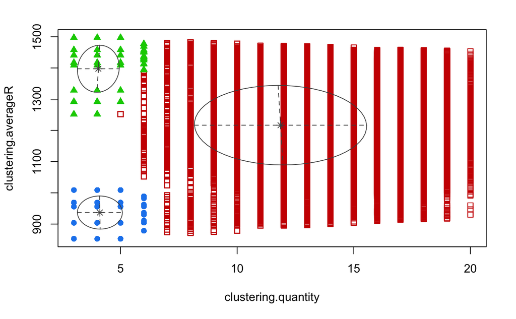

```r
plot(fit,what="classification")
```

Customer behavour

```r
#install.packages("rpart","rpart.plot")
require(rpart)
require(rpart.plot)

#split
data = mapping[, c(4,5,6,7)]
data
```

| product | quantity | Manuifactor | Price |
| --- | --- | --- | --- |
| Warspite figure | 3 | KOTOBUKIYA | 1458 |
| Lucifer | 3 | Hobby Japan | 904 |
| figma Nagato | 3 | AGP | 1409 |
| Mammon | 5 | Hobby Japan | 969 |
| Asmodeus | 3 | Hobby Japan | 1292 |
| Lucifer | 4 | Hobby Japan | 904 |
| Beelzebub | 3 | Hobby Japan | 1441 |
| Leviathan | 5 | Hobby Japan | 1497 |
| Maria Totsuka | 5 | Hobby Japan | 1417 |
| figma Nagato | 5 | AGP | 1409 |

[output cut: 990 more lines]

```r
data$Manuifactor[data$Manuifactor == "KOTOBUKIYA"] <- 1
data$Manuifactor[data$Manuifactor == "Hobby Japan"] <- 2
data$Manuifactor[data$Manuifactor == "AGP"] <- 3
data
```

| product | quantity | Manuifactor | Price |
| --- | --- | --- | --- |
| Warspite figure | 3 | 1 | 1458 |
| Lucifer | 3 | 2 | 904 |
| figma Nagato | 3 | 3 | 1409 |
| Mammon | 5 | 2 | 969 |
| Asmodeus | 3 | 2 | 1292 |
| Lucifer | 4 | 2 | 904 |
| Beelzebub | 3 | 2 | 1441 |
| Leviathan | 5 | 2 | 1497 |
| Maria Totsuka | 5 | 2 | 1417 |
| figma Nagato | 5 | 3 | 1409 |

[output cut: 990 more lines]

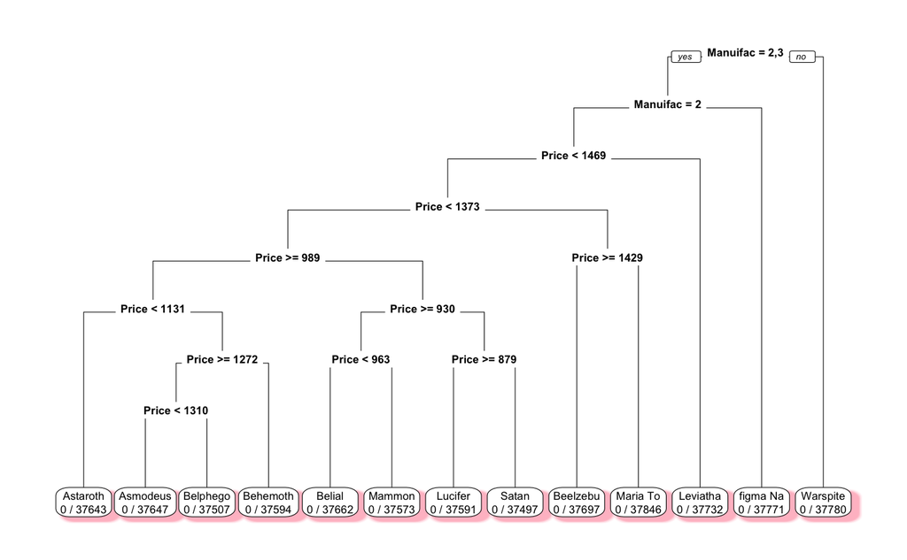

```r
train <- sample(nrow(data),0.8*nrow(data))
training <- data[train,]
testing <- data[-train,]
#plot the tree


model <- rpart(product ~ .,data=training)
prp(model, faclen =0, fallen.leaves = TRUE, shadow.col = "pink",extra = 3)
```

```r
NA
NA
NA
NA
```

Plot Revenue Map

```r
require(rworldmap)
require(rworldxtra)
require(Hmisc)

newmap <- getMap(resolution = "high")
plot(newmap, xlim=c(min(mapping$lon)-0.12,max(mapping$lon)+0.12), ylim=c(min(mapping$lat)-0.12,max(mapping$lat)+0.12),asp=1)
for (i in seq(nrow(finalMapping))) {
  subplot(barplot(height=as.integer(unname(unlist(finalMapping[finalMapping$branch==branch[i],c(2,3,4)]))), axes=F, col=rainbow(3)),
  x=finalMapping[finalMapping$branch==branch[i],6], y=finalMapping[finalMapping$branch==branch[i],5], size=c(.15, .15))
  text(x = finalMapping[finalMapping$branch==branch[i],6], y=finalMapping[finalMapping$branch==branch[i],5], branch[i],cex=.7,pos=1)
}
```

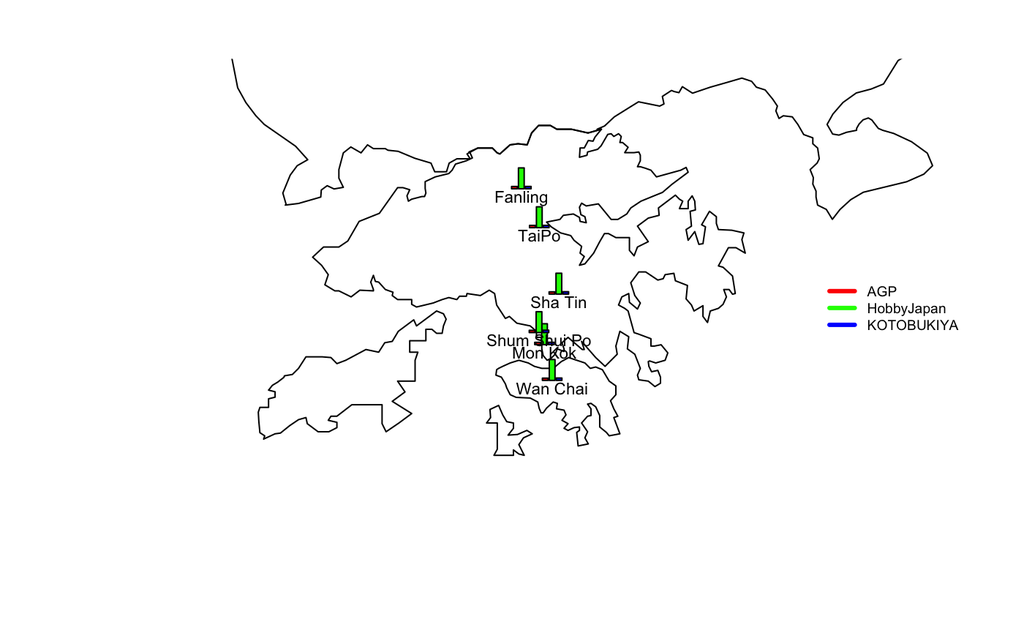

```r
legend("topright", c("AGP","HobbyJapan","KOTOBUKIYA"),xpd=T,inset=c(0,0.5),col=rainbow(3),cex=0.6,bty = "n",lwd = 3)
```

```r
NA
NA
```

For Evaluation part 1.How many products would you expected the customer to buy each time? The expected quantity of the good sold for each bill is around 11- 12. Therefore, the expected value is 11 to 12.

2.When is “retails winter” in this company and why?

Retail winter is Jan and Mar because the total revenue is the lowest in the year.

3.Which manuifacturs product(s) performs the best Revenue and why? (Hints: you may make assumption based on outcomes of the Revenue from branches by manufacturers)

Hobby Japan has the highest number of income on the branch graph.

5.State at least one customer decision-making pattern.

Customer will first consider the manufacturer and then price range will determine the major product name.